# MSDS 6306 Project 2

#Introduction DDSAnalytics has asked us to look into their talent management solutions. We were given three data sets which included a wide variety of information from their existing employees (such as Salary, Job Roles, Age, etc.). We do not have the actual reason an employee chose to leave the company (or stay), however we were able to use the data given to create and validate an attrition classification model. Also we built a predictive model for an employee’s monthly income.

# Libraries

```r
library(leaps)
library(plotROC)
library(caret)
library(mlr)
library(gmodels)
library(mosaic)
library(ggmosaic)
library(dplyr)
library(ggplot2)
library(tidyr)
#library(SDMTools)
library(readr)
library(digest)
library(ISLR)
library(leaps)
library( Matrix)
library(foreach)
library(glmnet)
library(VIM)
library(mice)
library(corrgram)
library(tidyverse)
#library(limma)
library(gridExtra)
library(MASS)
library(mvtnorm)
library(class)
library(e1071)
library(ResourceSelection)
```

```
## ResourceSelection 0.3-5   2019-07-22
```

```r
library(car)
library(mlbench)
library(GGally)
```

## Load the data

```r
setwd("C:/Users/BelajiAvvaru/Desktop/Docs/Docs/SMU/MSDS 6306/Project 2/")
ddsdata<-read.csv("CaseStudy2-data.csv",header=T)
head(ddsdata)
```

```
##   ID Age Attrition    BusinessTravel DailyRate             Department
## 1  1  32        No     Travel_Rarely       117                  Sales
## 2  2  40        No     Travel_Rarely      1308 Research & Development
## 3  3  35        No Travel_Frequently       200 Research & Development
## 4  4  32        No     Travel_Rarely       801                  Sales
## 5  5  24        No Travel_Frequently       567 Research & Development
## 6  6  27        No Travel_Frequently       294 Research & Development
##   DistanceFromHome Education   EducationField EmployeeCount EmployeeNumber
## 1               13         4    Life Sciences             1            859
## 2               14         3          Medical             1           1128
## 3               18         2    Life Sciences             1           1412
## 4                1         4        Marketing             1           2016
## 5                2         1 Technical Degree             1           1646
## 6               10         2    Life Sciences             1            733
##   EnvironmentSatisfaction Gender HourlyRate JobInvolvement JobLevel
```

[output cut: 41 more lines]

```r
summary(ddsdata$Attrition)
```

```
##  No Yes
## 730 140
```

# missing data

```
##  /\     /\
## {  `---'  }
## {  O   O  }
## ==>  V <==  No need for mice. This data set is completely observed.
##  \  \|/  /
##   `-----'
```

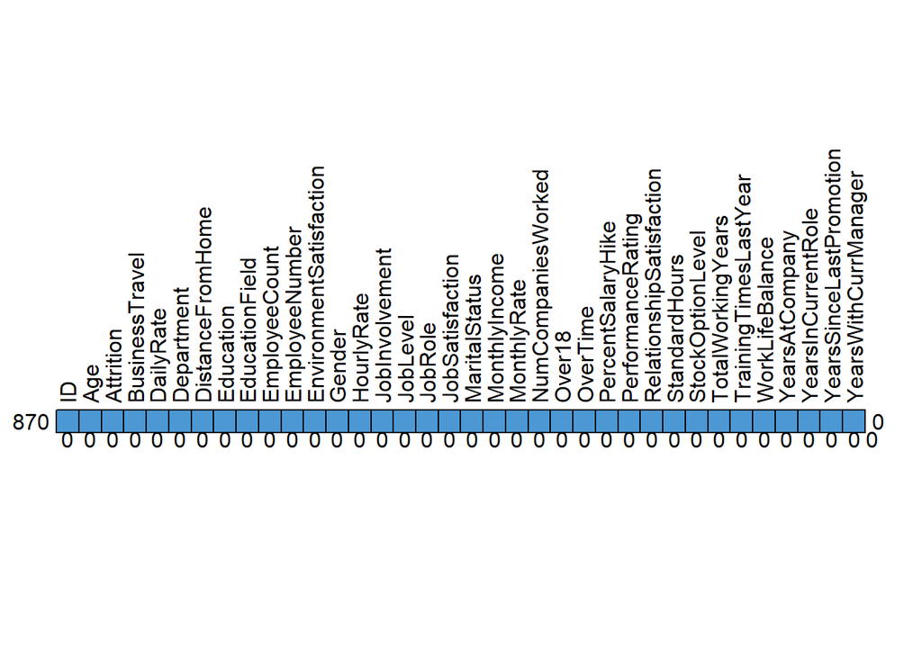

```
##     ID Age Attrition BusinessTravel DailyRate Department DistanceFromHome
## 870  1   1         1              1         1          1                1
##      0   0         0              0         0          0                0
##     Education EducationField EmployeeCount EmployeeNumber
## 870         1              1             1              1
##             0              0             0              0
##     EnvironmentSatisfaction Gender HourlyRate JobInvolvement JobLevel JobRole
## 870                       1      1          1              1        1       1
##                           0      0          0              0        0       0
##     JobSatisfaction MaritalStatus MonthlyIncome MonthlyRate NumCompaniesWorked
## 870               1             1             1           1                  1
##                   0             0             0           0                  0
##     Over18 OverTime PercentSalaryHike PerformanceRating
## 870      1        1                 1                 1
##          0        0                 0                 0
##     RelationshipSatisfaction StandardHours StockOptionLevel TotalWorkingYears
## 870                        1             1                1                 1
##                            0             0                0                 0
##     TrainingTimesLastYear WorkLifeBalance YearsAtCompany YearsInCurrentRole
## 870                     1               1              1                  1
##                         0               0              0                  0
##     YearsSinceLastPromotion YearsWithCurrManager
## 870                       1                    1 0
##                           0                    0 0
```

```r
#Display missing-data patterns
md.pattern(ddsdata, plot=TRUE, rotate.names = TRUE)
```

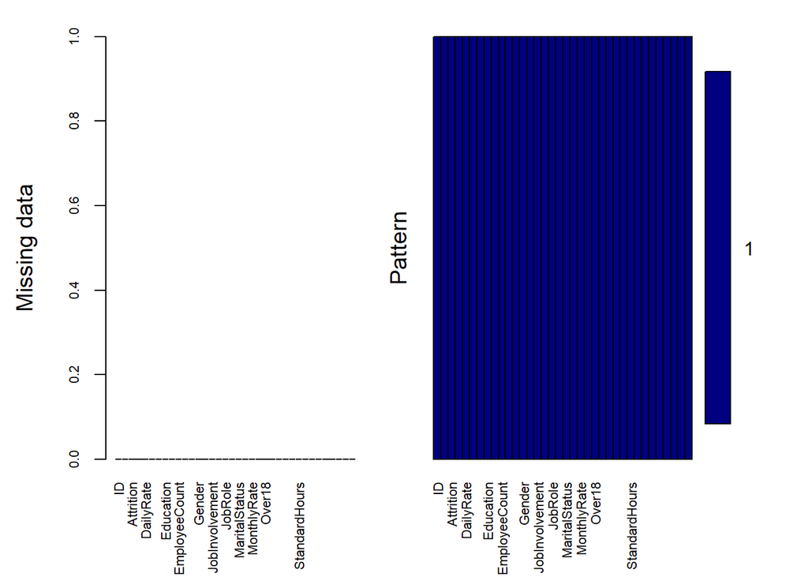

```
##
##  Variables sorted by number of missings:
##                  Variable Count
##                        ID     0
##                       Age     0
##                 Attrition     0
##            BusinessTravel     0
##                 DailyRate     0
##                Department     0
##          DistanceFromHome     0
##                 Education     0
##            EducationField     0
##             EmployeeCount     0
##            EmployeeNumber     0
##   EnvironmentSatisfaction     0
##                    Gender     0
##                HourlyRate     0
##            JobInvolvement     0
##                  JobLevel     0
##                   JobRole     0
##           JobSatisfaction     0
##             MaritalStatus     0
##             MonthlyIncome     0
##               MonthlyRate     0
##        NumCompaniesWorked     0
##                    Over18     0
##                  OverTime     0
##         PercentSalaryHike     0
##         PerformanceRating     0
##  RelationshipSatisfaction     0
##             StandardHours     0
##          StockOptionLevel     0
##         TotalWorkingYears     0
##     TrainingTimesLastYear     0
##           WorkLifeBalance     0
##            YearsAtCompany     0
##        YearsInCurrentRole     0
##   YearsSinceLastPromotion     0
##      YearsWithCurrManager     0
```

```r
#Display missing-data in a bar-plot
mice_plot <- aggr(ddsdata, col=c('navyblue','yellow'),
                  numbers=TRUE, sortVars=TRUE,
                  labels=names(ddsdata), cex.axis=.7,
                  gap=3, ylab=c("Missing data","Pattern"))
```

## No missing values in the dataset

## EDA on categorical variables

## “Attrition” “BusinessTravel” “Department” “EducationField” “Gender” “JobRole”

## “MaritalStatus” “Over18” “OverTime”

```r
catnames = names(ddsdata)[sapply(ddsdata, class) == "factor"]

catnames
```

```
## [1] "Attrition"      "BusinessTravel" "Department"     "EducationField"
## [5] "Gender"         "JobRole"        "MaritalStatus"  "Over18"
## [9] "OverTime"
```

```r
## Summary on OverTime variable,

summary(ddsdata$OverTime)
```

```
##  No Yes
## 618 252
```

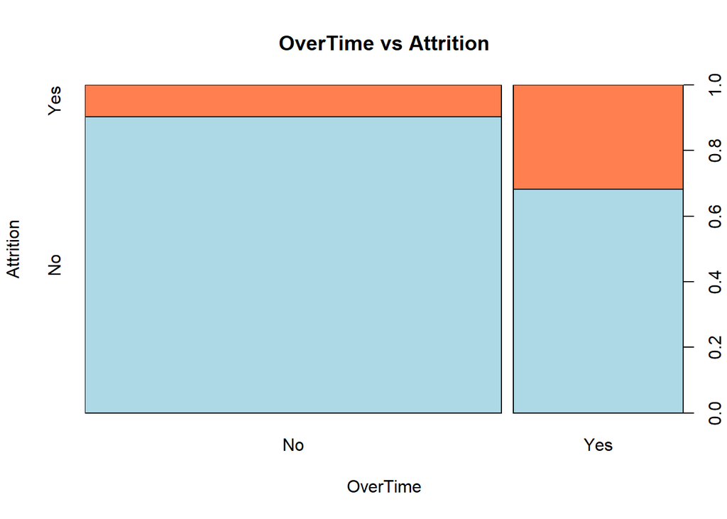

```r
spineplot(x = ddsdata$OverTime, y = ddsdata$Attrition, xlab = "OverTime", ylab = "Attrition",
          main = "OverTime vs Attrition", col = c("lightblue", "coral"), xaxlabels = levels(ddsdata$OverTime))
```

```r
CrossTable(ddsdata$OverTime, ddsdata$Attrition)
```

```
##
##
##    Cell Contents
## |-------------------------|
## |                       N |
## | Chi-square contribution |
## |           N / Row Total |
## |           N / Col Total |
## |         N / Table Total |
## |-------------------------|
##
##
## Total Observations in Table:  870
##
##
##                  | ddsdata$Attrition
## ddsdata$OverTime |        No |       Yes | Row Total |
## -----------------|-----------|-----------|-----------|
##               No |       558 |        60 |       618 |
##                  |     3.001 |    15.648 |           |
##                  |     0.903 |     0.097 |     0.710 |
##                  |     0.764 |     0.429 |           |
##                  |     0.641 |     0.069 |           |
## -----------------|-----------|-----------|-----------|
##              Yes |       172 |        80 |       252 |
##                  |     7.360 |    38.375 |           |
##                  |     0.683 |     0.317 |     0.290 |
##                  |     0.236 |     0.571 |           |
##                  |     0.198 |     0.092 |           |
## -----------------|-----------|-----------|-----------|
##     Column Total |       730 |       140 |       870 |
##                  |     0.839 |     0.161 |           |
## -----------------|-----------|-----------|-----------|
##
##
```

```r
chisq.test(ddsdata$OverTime, ddsdata$Attrition)
```

```
##
##  Pearson's Chi-squared test with Yates' continuity correction
##
## data:  ddsdata$OverTime and ddsdata$Attrition
## X-squared = 62.762, df = 1, p-value = 2.333e-15
```

```r
#OverTime has some difference in "yes" and "no" among its categories.
#P-value of  Chi-Square Test suggests that the variable "OverTime" has a  relationship with response variable. We can     keep this variable for final analysis
```

[output not shown]

```r
## Summary on Over18 variable, we can remove this varaible. all observations has value of "Y". This variable will not be useful in our analysis

summary(ddsdata$Over18)
```

```
##   Y
## 870
```

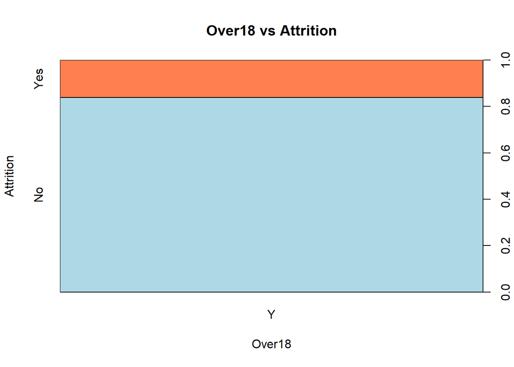

```r
spineplot(x = ddsdata$Over18, y = ddsdata$Attrition, xlab = "Over18", ylab = "Attrition",
          main = "Over18 vs Attrition", col = c("lightblue", "coral"), xaxlabels = levels(ddsdata$Over18))
```

```r
CrossTable(ddsdata$Over18, ddsdata$Attrition)
```

```
##
##
##    Cell Contents
## |-------------------------|
## |                       N |
## |         N / Table Total |
## |-------------------------|
##
##
## Total Observations in Table:  870
##
##
##                | ddsdata$Attrition
## ddsdata$Over18 |        No |       Yes | Row Total |
## ---------------|-----------|-----------|-----------|
##              Y |       730 |       140 |       870 |
##                |     0.839 |     0.161 |           |
## ---------------|-----------|-----------|-----------|
##   Column Total |       730 |       140 |       870 |
## ---------------|-----------|-----------|-----------|
##
##
```

```r
## Summary on MaritalStatus variable

summary(ddsdata$MaritalStatus)
```

```
## Divorced  Married   Single
##      191      410      269
```

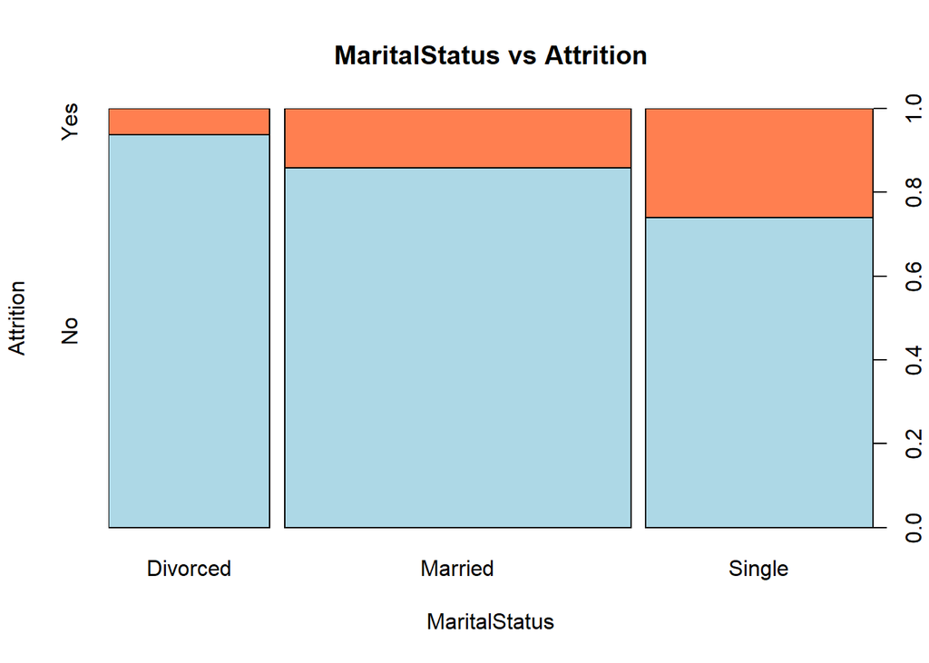

```r
spineplot(x = ddsdata$MaritalStatus, y = ddsdata$Attrition, xlab = "MaritalStatus", ylab = "Attrition",
          main = "MaritalStatus vs Attrition", col = c("lightblue", "coral"), xaxlabels = levels(ddsdata$MaritalStatus))
```

```r
CrossTable(ddsdata$MaritalStatus, ddsdata$Attrition)
```

```
##
##
##    Cell Contents
## |-------------------------|
## |                       N |
## | Chi-square contribution |
## |           N / Row Total |
## |           N / Col Total |
## |         N / Table Total |
## |-------------------------|
##
##
## Total Observations in Table:  870
##
##
##                       | ddsdata$Attrition
## ddsdata$MaritalStatus |        No |       Yes | Row Total |
## ----------------------|-----------|-----------|-----------|
##              Divorced |       179 |        12 |       191 |
##                       |     2.190 |    11.421 |           |
##                       |     0.937 |     0.063 |     0.220 |
##                       |     0.245 |     0.086 |           |
##                       |     0.206 |     0.014 |           |
## ----------------------|-----------|-----------|-----------|
##               Married |       352 |        58 |       410 |
##                       |     0.185 |     0.964 |           |
##                       |     0.859 |     0.141 |     0.471 |
##                       |     0.482 |     0.414 |           |
##                       |     0.405 |     0.067 |           |
## ----------------------|-----------|-----------|-----------|
##                Single |       199 |        70 |       269 |
##                       |     3.161 |    16.484 |           |
##                       |     0.740 |     0.260 |     0.309 |
##                       |     0.273 |     0.500 |           |
##                       |     0.229 |     0.080 |           |
## ----------------------|-----------|-----------|-----------|
##          Column Total |       730 |       140 |       870 |
##                       |     0.839 |     0.161 |           |
## ----------------------|-----------|-----------|-----------|
##
##
```

```r
chisq.test(ddsdata$MaritalStatus, ddsdata$Attrition)
```

```
##
##  Pearson's Chi-squared test
##
## data:  ddsdata$MaritalStatus and ddsdata$Attrition
## X-squared = 34.406, df = 2, p-value = 3.379e-08
```

```r
#MaritalStatus has some difference in "yes" and "no" among its categories. Married with 47.1%, Single with 30.9% and      divorced with 22%
#P-value of  Chi-Square Test suggests that the variable "MaritalStatus" has a  relationship with response variable. We    can keep this variable for final analysis
```

```r
## Summary on JobRole variable

summary(ddsdata$JobRole)
```

```
## Healthcare Representative           Human Resources     Laboratory Technician
##                        76                        27                       153
##                   Manager    Manufacturing Director         Research Director
##                        51                        87                        51
##        Research Scientist           Sales Executive      Sales Representative
##                       172                       200                        53
```

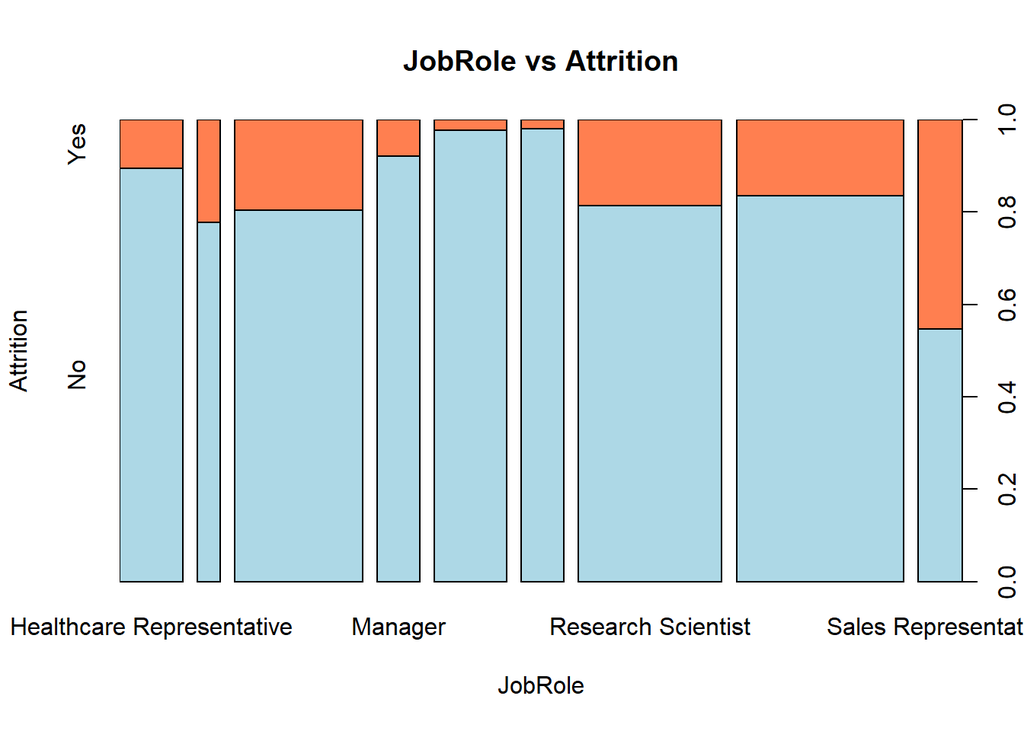

```r
spineplot(x = ddsdata$JobRole, y = ddsdata$Attrition, xlab = "JobRole", ylab = "Attrition",
          main = "JobRole vs Attrition", col = c("lightblue", "coral"), xaxlabels = levels(ddsdata$JobRole))
```

```r
CrossTable(ddsdata$JobRole, ddsdata$Attrition)
```

```
##
##
##    Cell Contents
## |-------------------------|
## |                       N |
## | Chi-square contribution |
## |           N / Row Total |
## |           N / Col Total |
## |         N / Table Total |
## |-------------------------|
##
##
## Total Observations in Table:  870
##
##
##                           | ddsdata$Attrition
##           ddsdata$JobRole |        No |       Yes | Row Total |
## --------------------------|-----------|-----------|-----------|
## Healthcare Representative |        68 |         8 |        76 |
##                           |     0.281 |     1.463 |           |
##                           |     0.895 |     0.105 |     0.087 |
##                           |     0.093 |     0.057 |           |
##                           |     0.078 |     0.009 |           |
## --------------------------|-----------|-----------|-----------|
##           Human Resources |        21 |         6 |        27 |
##                           |     0.121 |     0.631 |           |
##                           |     0.778 |     0.222 |     0.031 |
##                           |     0.029 |     0.043 |           |
##                           |     0.024 |     0.007 |           |
## --------------------------|-----------|-----------|-----------|
##     Laboratory Technician |       123 |        30 |       153 |
##                           |     0.225 |     1.175 |           |
##                           |     0.804 |     0.196 |     0.176 |
##                           |     0.168 |     0.214 |           |
##                           |     0.141 |     0.034 |           |
## --------------------------|-----------|-----------|-----------|
##                   Manager |        47 |         4 |        51 |
##                           |     0.414 |     2.156 |           |
##                           |     0.922 |     0.078 |     0.059 |
##                           |     0.064 |     0.029 |           |
```

[output cut: 22 more lines]

```
##                           |     0.835 |     0.165 |     0.230 |
##                           |     0.229 |     0.236 |           |
##                           |     0.192 |     0.038 |           |
## --------------------------|-----------|-----------|-----------|
##      Sales Representative |        29 |        24 |        53 |
##                           |     5.382 |    28.065 |           |
##                           |     0.547 |     0.453 |     0.061 |
##                           |     0.040 |     0.171 |           |
##                           |     0.033 |     0.028 |           |
## --------------------------|-----------|-----------|-----------|
##              Column Total |       730 |       140 |       870 |
##                           |     0.839 |     0.161 |           |
## --------------------------|-----------|-----------|-----------|
##
##
```

```r
chisq.test(ddsdata$JobRole, ddsdata$Attrition)
```

```
##
##  Pearson's Chi-squared test
##
## data:  ddsdata$JobRole and ddsdata$Attrition
## X-squared = 60.543, df = 8, p-value = 3.647e-10
```

```r
## JobRole has some difference in "yes" and "no" among its categories. Sales Executive at 23% and Human resource at 3.1%
## P-value of  Chi-Square Test suggests that the variable "JobRole" has a  relationship with response variable. We can keep this variable for final analysis
```

```r
## Summary on Gender variable

summary(ddsdata$Gender)
```

```
## Female   Male
##    354    516
```

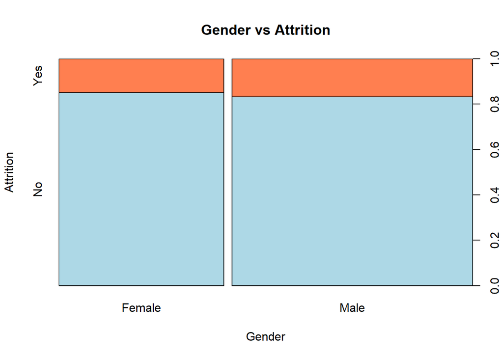

```r
spineplot(x = ddsdata$Gender, y = ddsdata$Attrition, xlab = "Gender", ylab = "Attrition",
          main = "Gender vs Attrition", col = c("lightblue", "coral"), xaxlabels = levels(ddsdata$Gender))
```

```r
CrossTable(ddsdata$Gender, ddsdata$Attrition)
```

```
##
##
##    Cell Contents
## |-------------------------|
## |                       N |
## | Chi-square contribution |
## |           N / Row Total |
## |           N / Col Total |
## |         N / Table Total |
## |-------------------------|
##
##
## Total Observations in Table:  870
##
##
##                | ddsdata$Attrition
## ddsdata$Gender |        No |       Yes | Row Total |
## ---------------|-----------|-----------|-----------|
##         Female |       301 |        53 |       354 |
##                |     0.053 |     0.276 |           |
##                |     0.850 |     0.150 |     0.407 |
##                |     0.412 |     0.379 |           |
##                |     0.346 |     0.061 |           |
## ---------------|-----------|-----------|-----------|
##           Male |       429 |        87 |       516 |
##                |     0.036 |     0.189 |           |
##                |     0.831 |     0.169 |     0.593 |
##                |     0.588 |     0.621 |           |
##                |     0.493 |     0.100 |           |
## ---------------|-----------|-----------|-----------|
##   Column Total |       730 |       140 |       870 |
##                |     0.839 |     0.161 |           |
## ---------------|-----------|-----------|-----------|
##
##
```

```r
chisq.test(ddsdata$Gender, ddsdata$Attrition)
```

```
##
##  Pearson's Chi-squared test with Yates' continuity correction
##
## data:  ddsdata$Gender and ddsdata$Attrition
## X-squared = 0.42363, df = 1, p-value = 0.5151
```

```r
## Gender has no difference in "yes" and "no" among its categories. pretty much both categories with around 85% and 15% of "no" and "yes" respectively
## P-value of  Chi-Square Test suggests that the variable "Gender" has no relationship with response variable. We can remove this variable for final analysis
```

```r
## Summary on EducationField variable

summary(ddsdata$EducationField)
```

```
##  Human Resources    Life Sciences        Marketing          Medical
##               15              358              100              270
##            Other Technical Degree
##               52               75
```

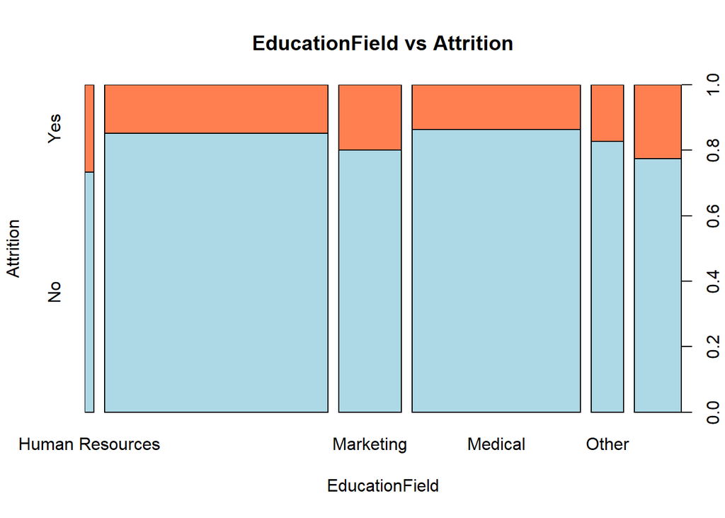

```r
spineplot(x = ddsdata$EducationField, y = ddsdata$Attrition, xlab = "EducationField", ylab = "Attrition",
          main = "EducationField vs Attrition", col = c("lightblue", "coral"), xaxlabels = levels(ddsdata$EducationField))
```

```r
CrossTable(ddsdata$EducationField, ddsdata$Attrition)
```

```
##
##
##    Cell Contents
## |-------------------------|
## |                       N |
## | Chi-square contribution |
## |           N / Row Total |
## |           N / Col Total |
## |         N / Table Total |
## |-------------------------|
##
##
## Total Observations in Table:  870
##
##
##                        | ddsdata$Attrition
## ddsdata$EducationField |        No |       Yes | Row Total |
## -----------------------|-----------|-----------|-----------|
##        Human Resources |        11 |         4 |        15 |
##                        |     0.200 |     1.042 |           |
##                        |     0.733 |     0.267 |     0.017 |
##                        |     0.015 |     0.029 |           |
##                        |     0.013 |     0.005 |           |
## -----------------------|-----------|-----------|-----------|
##          Life Sciences |       305 |        53 |       358 |
##                        |     0.071 |     0.369 |           |
##                        |     0.852 |     0.148 |     0.411 |
##                        |     0.418 |     0.379 |           |
##                        |     0.351 |     0.061 |           |
## -----------------------|-----------|-----------|-----------|
##              Marketing |        80 |        20 |       100 |
##                        |     0.182 |     0.949 |           |
##                        |     0.800 |     0.200 |     0.115 |
##                        |     0.110 |     0.143 |           |
##                        |     0.092 |     0.023 |           |
## -----------------------|-----------|-----------|-----------|
##                Medical |       233 |        37 |       270 |
##                        |     0.184 |     0.957 |           |
##                        |     0.863 |     0.137 |     0.310 |
##                        |     0.319 |     0.264 |           |
##                        |     0.268 |     0.043 |           |
## -----------------------|-----------|-----------|-----------|
##                  Other |        43 |         9 |        52 |
##                        |     0.009 |     0.048 |           |
##                        |     0.827 |     0.173 |     0.060 |
##                        |     0.059 |     0.064 |           |
##                        |     0.049 |     0.010 |           |
## -----------------------|-----------|-----------|-----------|
##       Technical Degree |        58 |        17 |        75 |
##                        |     0.386 |     2.015 |           |
##                        |     0.773 |     0.227 |     0.086 |
##                        |     0.079 |     0.121 |           |
##                        |     0.067 |     0.020 |           |
## -----------------------|-----------|-----------|-----------|
##           Column Total |       730 |       140 |       870 |
##                        |     0.839 |     0.161 |           |
## -----------------------|-----------|-----------|-----------|
##
##
```

```r
chisq.test(ddsdata$EducationField, ddsdata$Attrition)
```

```
##
##  Pearson's Chi-squared test
##
## data:  ddsdata$EducationField and ddsdata$Attrition
## X-squared = 6.4114, df = 5, p-value = 0.2682
```

```r
## EducationField has difference in "yes" and "no" among its categories.
## But P-value of  Chi-Square Test suggests that the variable "EducationField" has no relationship with response variable. We can remove this variable for final analysis
```

```r
## Summary on Department variable

summary(ddsdata$Department)
```

```
##        Human Resources Research & Development                  Sales
##                     35                    562                    273
```

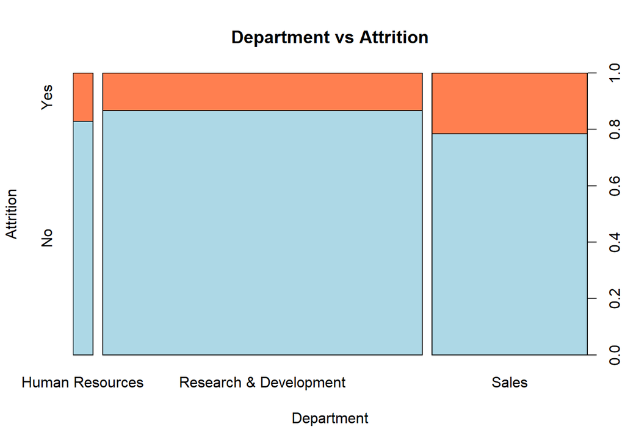

```r
spineplot(x = ddsdata$Department, y = ddsdata$Attrition, xlab = "Department", ylab = "Attrition",
          main = "Department vs Attrition", col = c("lightblue", "coral"), xaxlabels = levels(ddsdata$Department))
```

```r
CrossTable(ddsdata$Department, ddsdata$Attrition)
```

```
##
##
##    Cell Contents
## |-------------------------|
## |                       N |
## | Chi-square contribution |
## |           N / Row Total |
## |           N / Col Total |
## |         N / Table Total |
## |-------------------------|
##
##
## Total Observations in Table:  870
##
##
##                        | ddsdata$Attrition
##     ddsdata$Department |        No |       Yes | Row Total |
## -----------------------|-----------|-----------|-----------|
##        Human Resources |        29 |         6 |        35 |
##                        |     0.005 |     0.024 |           |
##                        |     0.829 |     0.171 |     0.040 |
##                        |     0.040 |     0.043 |           |
##                        |     0.033 |     0.007 |           |
## -----------------------|-----------|-----------|-----------|
## Research & Development |       487 |        75 |       562 |
##                        |     0.505 |     2.635 |           |
##                        |     0.867 |     0.133 |     0.646 |
##                        |     0.667 |     0.536 |           |
##                        |     0.560 |     0.086 |           |
## -----------------------|-----------|-----------|-----------|
##                  Sales |       214 |        59 |       273 |
##                        |     0.991 |     5.169 |           |
##                        |     0.784 |     0.216 |     0.314 |
##                        |     0.293 |     0.421 |           |
##                        |     0.246 |     0.068 |           |
## -----------------------|-----------|-----------|-----------|
##           Column Total |       730 |       140 |       870 |
##                        |     0.839 |     0.161 |           |
## -----------------------|-----------|-----------|-----------|
##
##
```

```r
chisq.test(ddsdata$Department, ddsdata$Attrition)
```

```
##
##  Pearson's Chi-squared test
##
## data:  ddsdata$Department and ddsdata$Attrition
## X-squared = 9.329, df = 2, p-value = 0.009424
```

```r
## Department has difference in "yes" and "no" among its categories.
## But P-value of  Chi-Square Test suggests that the variable "Department" has a relationship with response variable. We can keep this variable for final analysis
```

```r
## Summary on BusinessTravel variable

summary(ddsdata$BusinessTravel)
```

```
##        Non-Travel Travel_Frequently     Travel_Rarely
##                94               158               618
```

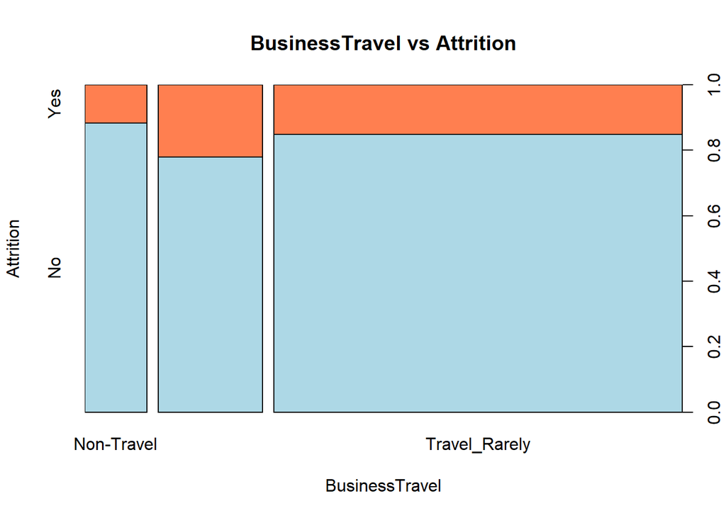

```r
spineplot(x = ddsdata$BusinessTravel, y = ddsdata$Attrition, xlab = "BusinessTravel", ylab = "Attrition",
          main = "BusinessTravel vs Attrition", col = c("lightblue", "coral"), xaxlabels = levels(ddsdata$BusinessTravel))
```

```r
CrossTable(ddsdata$BusinessTravel, ddsdata$Attrition)
```

```
##
##
##    Cell Contents
## |-------------------------|
## |                       N |
## | Chi-square contribution |
## |           N / Row Total |
## |           N / Col Total |
## |         N / Table Total |
## |-------------------------|
##
##
## Total Observations in Table:  870
##
##
##                        | ddsdata$Attrition
## ddsdata$BusinessTravel |        No |       Yes | Row Total |
## -----------------------|-----------|-----------|-----------|
##             Non-Travel |        83 |        11 |        94 |
##                        |     0.216 |     1.126 |           |
##                        |     0.883 |     0.117 |     0.108 |
##                        |     0.114 |     0.079 |           |
##                        |     0.095 |     0.013 |           |
## -----------------------|-----------|-----------|-----------|
##      Travel_Frequently |       123 |        35 |       158 |
##                        |     0.691 |     3.606 |           |
##                        |     0.778 |     0.222 |     0.182 |
##                        |     0.168 |     0.250 |           |
##                        |     0.141 |     0.040 |           |
## -----------------------|-----------|-----------|-----------|
##          Travel_Rarely |       524 |        94 |       618 |
##                        |     0.057 |     0.298 |           |
##                        |     0.848 |     0.152 |     0.710 |
##                        |     0.718 |     0.671 |           |
##                        |     0.602 |     0.108 |           |
## -----------------------|-----------|-----------|-----------|
##           Column Total |       730 |       140 |       870 |
##                        |     0.839 |     0.161 |           |
## -----------------------|-----------|-----------|-----------|
##
##
```

```r
chisq.test(ddsdata$BusinessTravel, ddsdata$Attrition)
```

```
##
##  Pearson's Chi-squared test
##
## data:  ddsdata$BusinessTravel and ddsdata$Attrition
## X-squared = 5.9945, df = 2, p-value = 0.04993
```

```r
## BusinessTravel has difference in "yes" and "no" among its categories.
## But P-value of  Chi-Square Test suggests that the variable "BusinessTravel" has a relationship with response variable. We can keep this variable for final analysis
```

# Observations

Based on the Bar plots and Chi-squared test, following variables are significant with response variable BusinessTravel Department JobRole MaritalStatus OverTime

```r
####Some of the variables are interger variables, but these variables should actually be categorical and therefore will be converted to factors

ddsdata$Education <- as.factor(ddsdata$Education)
ddsdata$EnvironmentSatisfaction <- as.factor(ddsdata$EnvironmentSatisfaction)
ddsdata$JobInvolvement <- as.factor(ddsdata$JobInvolvement)
ddsdata$JobLevel <- as.factor(ddsdata$JobLevel)
ddsdata$JobSatisfaction <- as.factor(ddsdata$JobSatisfaction)
ddsdata$PerformanceRating <- as.factor(ddsdata$PerformanceRating)
ddsdata$RelationshipSatisfaction <- as.factor(ddsdata$RelationshipSatisfaction)
ddsdata$StockOptionLevel <- as.factor(ddsdata$StockOptionLevel)
ddsdata$TrainingTimesLastYear <- as.factor(ddsdata$TrainingTimesLastYear)
ddsdata$WorkLifeBalance <- as.factor(ddsdata$WorkLifeBalance)
```

```r
## Summary on Education variable

summary(ddsdata$Education)
```

```
##   1   2   3   4   5
##  98 182 324 240  26
```

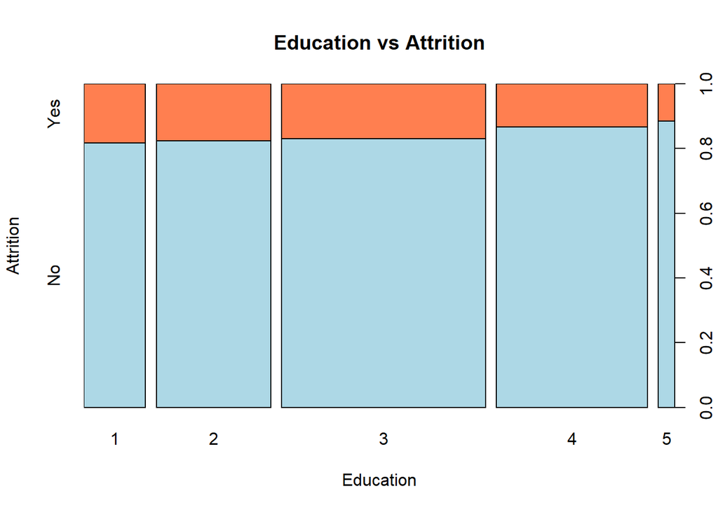

```r
spineplot(x = ddsdata$Education, y = ddsdata$Attrition, xlab = "Education", ylab = "Attrition",
          main = "Education vs Attrition", col = c("lightblue", "coral"), xaxlabels = levels(ddsdata$Education))
```

```r
CrossTable(ddsdata$Education, ddsdata$Attrition)
```

```
##
##
##    Cell Contents
## |-------------------------|
## |                       N |
## | Chi-square contribution |
## |           N / Row Total |
## |           N / Col Total |
## |         N / Table Total |
## |-------------------------|
##
##
## Total Observations in Table:  870
##
##
##                   | ddsdata$Attrition
## ddsdata$Education |        No |       Yes | Row Total |
## ------------------|-----------|-----------|-----------|
##                 1 |        80 |        18 |        98 |
##                   |     0.060 |     0.315 |           |
##                   |     0.816 |     0.184 |     0.113 |
##                   |     0.110 |     0.129 |           |
##                   |     0.092 |     0.021 |           |
## ------------------|-----------|-----------|-----------|
##                 2 |       150 |        32 |       182 |
##                   |     0.048 |     0.251 |           |
##                   |     0.824 |     0.176 |     0.209 |
##                   |     0.205 |     0.229 |           |
##                   |     0.172 |     0.037 |           |
## ------------------|-----------|-----------|-----------|
##                 3 |       269 |        55 |       324 |
##                   |     0.030 |     0.157 |           |
##                   |     0.830 |     0.170 |     0.372 |
##                   |     0.368 |     0.393 |           |
##                   |     0.309 |     0.063 |           |
## ------------------|-----------|-----------|-----------|
##                 4 |       208 |        32 |       240 |
##                   |     0.218 |     1.135 |           |
##                   |     0.867 |     0.133 |     0.276 |
##                   |     0.285 |     0.229 |           |
##                   |     0.239 |     0.037 |           |
## ------------------|-----------|-----------|-----------|
##                 5 |        23 |         3 |        26 |
##                   |     0.064 |     0.335 |           |
##                   |     0.885 |     0.115 |     0.030 |
##                   |     0.032 |     0.021 |           |
##                   |     0.026 |     0.003 |           |
## ------------------|-----------|-----------|-----------|
##      Column Total |       730 |       140 |       870 |
##                   |     0.839 |     0.161 |           |
## ------------------|-----------|-----------|-----------|
##
##
```

```r
chisq.test(ddsdata$Education, ddsdata$Attrition)
```

```
##
##  Pearson's Chi-squared test
##
## data:  ddsdata$Education and ddsdata$Attrition
## X-squared = 2.6143, df = 4, p-value = 0.6243
```

```r
## Education has difference in "yes" and "no" among its categories.
## But P-value of  Chi-Square Test suggests that the variable "Education" has no relationship with response variable. We can remove this variable for final analysis
```

```r
## Summary on EnvironmentSatisfaction variable

summary(ddsdata$EnvironmentSatisfaction)
```

```
##   1   2   3   4
## 172 178 258 262
```

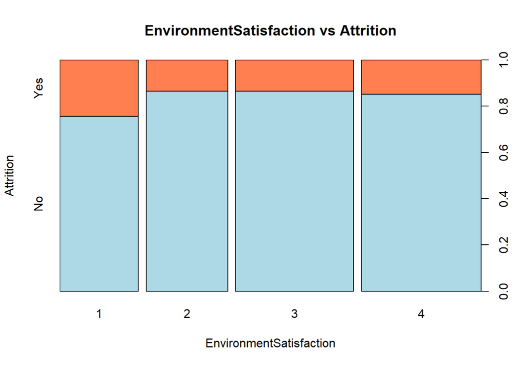

```r
spineplot(x = ddsdata$EnvironmentSatisfaction, y = ddsdata$Attrition, xlab = "EnvironmentSatisfaction", ylab = "Attrition",
          main = "EnvironmentSatisfaction vs Attrition", col = c("lightblue", "coral"), xaxlabels = levels(ddsdata$EnvironmentSatisfaction))
```

```r
CrossTable(ddsdata$EnvironmentSatisfaction, ddsdata$Attrition)
```

```
##
##
##    Cell Contents
## |-------------------------|
## |                       N |
## | Chi-square contribution |
## |           N / Row Total |
## |           N / Col Total |
## |         N / Table Total |
## |-------------------------|
##
##
## Total Observations in Table:  870
##
##
##                                 | ddsdata$Attrition
## ddsdata$EnvironmentSatisfaction |        No |       Yes | Row Total |
## --------------------------------|-----------|-----------|-----------|
##                               1 |       130 |        42 |       172 |
##                                 |     1.421 |     7.411 |           |
##                                 |     0.756 |     0.244 |     0.198 |
##                                 |     0.178 |     0.300 |           |
##                                 |     0.149 |     0.048 |           |
## --------------------------------|-----------|-----------|-----------|
##                               2 |       154 |        24 |       178 |
##                                 |     0.144 |     0.753 |           |
##                                 |     0.865 |     0.135 |     0.205 |
##                                 |     0.211 |     0.171 |           |
##                                 |     0.177 |     0.028 |           |
## --------------------------------|-----------|-----------|-----------|
##                               3 |       223 |        35 |       258 |
##                                 |     0.196 |     1.023 |           |
##                                 |     0.864 |     0.136 |     0.297 |
##                                 |     0.305 |     0.250 |           |
##                                 |     0.256 |     0.040 |           |
## --------------------------------|-----------|-----------|-----------|
##                               4 |       223 |        39 |       262 |
##                                 |     0.045 |     0.237 |           |
##                                 |     0.851 |     0.149 |     0.301 |
##                                 |     0.305 |     0.279 |           |
##                                 |     0.256 |     0.045 |           |
## --------------------------------|-----------|-----------|-----------|
##                    Column Total |       730 |       140 |       870 |
##                                 |     0.839 |     0.161 |           |
## --------------------------------|-----------|-----------|-----------|
##
##
```

```r
chisq.test(ddsdata$EnvironmentSatisfaction, ddsdata$Attrition)
```

```
##
##  Pearson's Chi-squared test
##
## data:  ddsdata$EnvironmentSatisfaction and ddsdata$Attrition
## X-squared = 11.231, df = 3, p-value = 0.01054
```

```r
## EnvironmentSatisfaction has difference in "yes" and "no" among its categories.
## But P-value of  Chi-Square Test suggests that the variable "EnvironmentSatisfaction" has a relationship with response variable. We can keep this variable for final analysis
```

```r
## Summary on JobInvolvement variable

summary(ddsdata$JobInvolvement)
```

```
##   1   2   3   4
##  47 228 514  81
```

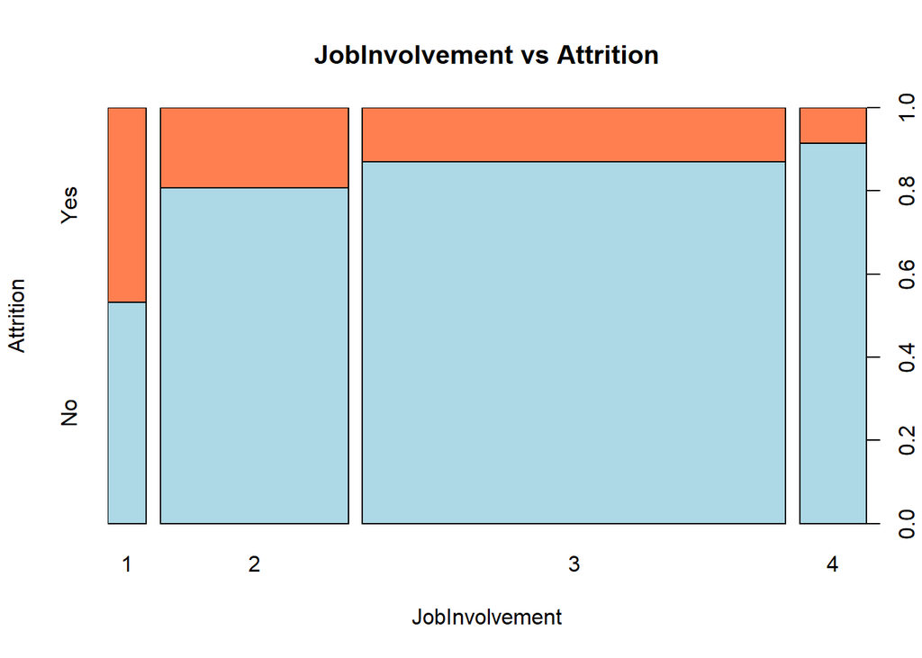

```r
spineplot(x = ddsdata$JobInvolvement, y = ddsdata$Attrition, xlab = "JobInvolvement", ylab = "Attrition",
          main = "JobInvolvement vs Attrition", col = c("lightblue", "coral"), xaxlabels = levels(ddsdata$JobInvolvement))
```

```r
CrossTable(ddsdata$JobInvolvement, ddsdata$Attrition)
```

```
##
##
##    Cell Contents
## |-------------------------|
## |                       N |
## | Chi-square contribution |
## |           N / Row Total |
## |           N / Col Total |
## |         N / Table Total |
## |-------------------------|
##
##
## Total Observations in Table:  870
##
##
##                        | ddsdata$Attrition
## ddsdata$JobInvolvement |        No |       Yes | Row Total |
## -----------------------|-----------|-----------|-----------|
##                      1 |        25 |        22 |        47 |
##                        |     5.285 |    27.557 |           |
##                        |     0.532 |     0.468 |     0.054 |
##                        |     0.034 |     0.157 |           |
##                        |     0.029 |     0.025 |           |
## -----------------------|-----------|-----------|-----------|
##                      2 |       184 |        44 |       228 |
##                        |     0.279 |     1.457 |           |
##                        |     0.807 |     0.193 |     0.262 |
##                        |     0.252 |     0.314 |           |
##                        |     0.211 |     0.051 |           |
## -----------------------|-----------|-----------|-----------|
##                      3 |       447 |        67 |       514 |
##                        |     0.572 |     2.985 |           |
##                        |     0.870 |     0.130 |     0.591 |
##                        |     0.612 |     0.479 |           |
##                        |     0.514 |     0.077 |           |
## -----------------------|-----------|-----------|-----------|
##                      4 |        74 |         7 |        81 |
##                        |     0.536 |     2.794 |           |
##                        |     0.914 |     0.086 |     0.093 |
##                        |     0.101 |     0.050 |           |
##                        |     0.085 |     0.008 |           |
## -----------------------|-----------|-----------|-----------|
##           Column Total |       730 |       140 |       870 |
##                        |     0.839 |     0.161 |           |
## -----------------------|-----------|-----------|-----------|
##
##
```

```r
chisq.test(ddsdata$JobInvolvement, ddsdata$Attrition)
```

```
##
##  Pearson's Chi-squared test
##
## data:  ddsdata$JobInvolvement and ddsdata$Attrition
## X-squared = 41.465, df = 3, p-value = 5.211e-09
```

```r
## JobInvolvement has difference in "yes" and "no" among its categories.
## But P-value of  Chi-Square Test suggests that the variable "JobInvolvement" has a relationship with response variable. We can keep this variable for final analysis
```

```r
## Summary on JobLevel variable

summary(ddsdata$JobLevel)
```

```
##   1   2   3   4   5
## 329 312 132  60  37
```

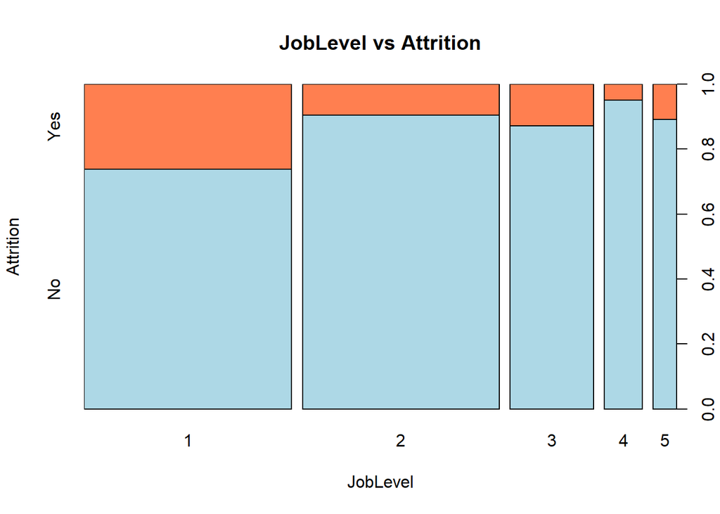

```r
spineplot(x = ddsdata$JobLevel, y = ddsdata$Attrition, xlab = "JobLevel", ylab = "Attrition",
          main = "JobLevel vs Attrition", col = c("lightblue", "coral"), xaxlabels = levels(ddsdata$JobLevel))
```

```r
CrossTable(ddsdata$JobLevel, ddsdata$Attrition)
```

```
##
##
##    Cell Contents
## |-------------------------|
## |                       N |
## | Chi-square contribution |
## |           N / Row Total |
## |           N / Col Total |
## |         N / Table Total |
## |-------------------------|
##
##
## Total Observations in Table:  870
##
##
##                  | ddsdata$Attrition
## ddsdata$JobLevel |        No |       Yes | Row Total |
## -----------------|-----------|-----------|-----------|
##                1 |       243 |        86 |       329 |
##                  |     3.959 |    20.641 |           |
##                  |     0.739 |     0.261 |     0.378 |
##                  |     0.333 |     0.614 |           |
##                  |     0.279 |     0.099 |           |
## -----------------|-----------|-----------|-----------|
##                2 |       282 |        30 |       312 |
##                  |     1.560 |     8.133 |           |
##                  |     0.904 |     0.096 |     0.359 |
##                  |     0.386 |     0.214 |           |
##                  |     0.324 |     0.034 |           |
## -----------------|-----------|-----------|-----------|
##                3 |       115 |        17 |       132 |
##                  |     0.162 |     0.847 |           |
##                  |     0.871 |     0.129 |     0.152 |
##                  |     0.158 |     0.121 |           |
##                  |     0.132 |     0.020 |           |
## -----------------|-----------|-----------|-----------|
##                4 |        57 |         3 |        60 |
##                  |     0.880 |     4.587 |           |
##                  |     0.950 |     0.050 |     0.069 |
##                  |     0.078 |     0.021 |           |
##                  |     0.066 |     0.003 |           |
## -----------------|-----------|-----------|-----------|
##                5 |        33 |         4 |        37 |
##                  |     0.123 |     0.641 |           |
##                  |     0.892 |     0.108 |     0.043 |
##                  |     0.045 |     0.029 |           |
##                  |     0.038 |     0.005 |           |
## -----------------|-----------|-----------|-----------|
##     Column Total |       730 |       140 |       870 |
##                  |     0.839 |     0.161 |           |
## -----------------|-----------|-----------|-----------|
##
##
```

```r
chisq.test(ddsdata$JobLevel, ddsdata$Attrition)
```

```
##
##  Pearson's Chi-squared test
##
## data:  ddsdata$JobLevel and ddsdata$Attrition
## X-squared = 41.533, df = 4, p-value = 2.085e-08
```

```r
## JobLevel has difference in "yes" and "no" among its categories.
## But P-value of  Chi-Square Test suggests that the variable "JobLevel" has a relationship with response variable. We can keep this variable for final analysis
```

```r
## Summary on JobSatisfaction variable

summary(ddsdata$JobSatisfaction)
```

```
##   1   2   3   4
## 179 166 254 271
```

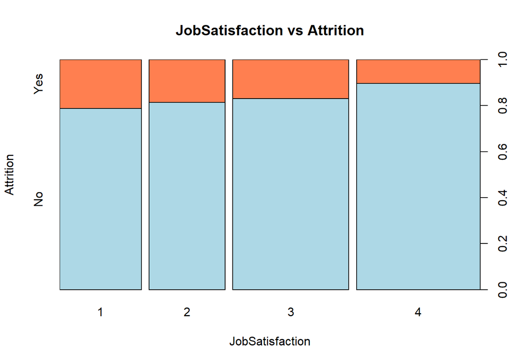

```r
spineplot(x = ddsdata$JobSatisfaction, y = ddsdata$Attrition, xlab = "JobSatisfaction", ylab = "Attrition",
          main = "JobSatisfaction vs Attrition", col = c("lightblue", "coral"), xaxlabels = levels(ddsdata$JobSatisfaction))
```

```r
CrossTable(ddsdata$JobSatisfaction, ddsdata$Attrition)
```

```
##
##
##    Cell Contents
## |-------------------------|
## |                       N |
## | Chi-square contribution |
## |           N / Row Total |
## |           N / Col Total |
## |         N / Table Total |
## |-------------------------|
##
##
## Total Observations in Table:  870
##
##
##                         | ddsdata$Attrition
## ddsdata$JobSatisfaction |        No |       Yes | Row Total |
## ------------------------|-----------|-----------|-----------|
##                       1 |       141 |        38 |       179 |
##                         |     0.563 |     2.935 |           |
##                         |     0.788 |     0.212 |     0.206 |
##                         |     0.193 |     0.271 |           |
##                         |     0.162 |     0.044 |           |
## ------------------------|-----------|-----------|-----------|
##                       2 |       135 |        31 |       166 |
##                         |     0.132 |     0.688 |           |
##                         |     0.813 |     0.187 |     0.191 |
##                         |     0.185 |     0.221 |           |
##                         |     0.155 |     0.036 |           |
## ------------------------|-----------|-----------|-----------|
##                       3 |       211 |        43 |       254 |
##                         |     0.021 |     0.111 |           |
##                         |     0.831 |     0.169 |     0.292 |
##                         |     0.289 |     0.307 |           |
##                         |     0.243 |     0.049 |           |
## ------------------------|-----------|-----------|-----------|
##                       4 |       243 |        28 |       271 |
##                         |     1.071 |     5.587 |           |
##                         |     0.897 |     0.103 |     0.311 |
##                         |     0.333 |     0.200 |           |
##                         |     0.279 |     0.032 |           |
## ------------------------|-----------|-----------|-----------|
##            Column Total |       730 |       140 |       870 |
##                         |     0.839 |     0.161 |           |
## ------------------------|-----------|-----------|-----------|
##
##
```

```r
chisq.test(ddsdata$JobSatisfaction, ddsdata$Attrition)
```

```
##
##  Pearson's Chi-squared test
##
## data:  ddsdata$JobSatisfaction and ddsdata$Attrition
## X-squared = 11.109, df = 3, p-value = 0.01115
```

```r
## JobSatisfaction has difference in "yes" and "no" among its categories.
## But P-value of  Chi-Square Test suggests that the variable "JobSatisfaction" has a relationship with response variable. We can keep this variable for final analysis
```

```r
## Summary on PerformanceRating variable

summary(ddsdata$PerformanceRating)
```

```
##   3   4
## 738 132
```

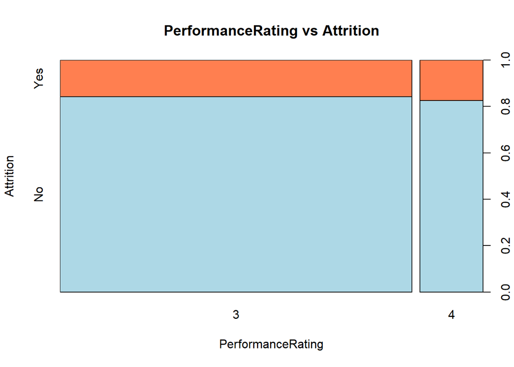

```r
spineplot(x = ddsdata$PerformanceRating, y = ddsdata$Attrition, xlab = "PerformanceRating", ylab = "Attrition",
          main = "PerformanceRating vs Attrition", col = c("lightblue", "coral"), xaxlabels = levels(ddsdata$PerformanceRating))
```

```r
CrossTable(ddsdata$PerformanceRating, ddsdata$Attrition)
```

```
##
##
##    Cell Contents
## |-------------------------|
## |                       N |
## | Chi-square contribution |
## |           N / Row Total |
## |           N / Col Total |
## |         N / Table Total |
## |-------------------------|
##
##
## Total Observations in Table:  870
##
##
##                           | ddsdata$Attrition
## ddsdata$PerformanceRating |        No |       Yes | Row Total |
## --------------------------|-----------|-----------|-----------|
##                         3 |       621 |       117 |       738 |
##                           |     0.005 |     0.026 |           |
##                           |     0.841 |     0.159 |     0.848 |
##                           |     0.851 |     0.836 |           |
##                           |     0.714 |     0.134 |           |
## --------------------------|-----------|-----------|-----------|
##                         4 |       109 |        23 |       132 |
##                           |     0.028 |     0.146 |           |
##                           |     0.826 |     0.174 |     0.152 |
##                           |     0.149 |     0.164 |           |
##                           |     0.125 |     0.026 |           |
## --------------------------|-----------|-----------|-----------|
##              Column Total |       730 |       140 |       870 |
##                           |     0.839 |     0.161 |           |
## --------------------------|-----------|-----------|-----------|
##
##
```

```r
chisq.test(ddsdata$PerformanceRating, ddsdata$Attrition)
```

```
##
##  Pearson's Chi-squared test with Yates' continuity correction
##
## data:  ddsdata$PerformanceRating and ddsdata$Attrition
## X-squared = 0.10478, df = 1, p-value = 0.7462
```

```r
## PerformanceRating has difference in "yes" and "no" among its categories.
## But P-value of  Chi-Square Test suggests that the variable "PerformanceRating" has no relationship with response variable. We can remove this variable for final analysis
```

```r
## Summary on RelationshipSatisfaction variable

summary(ddsdata$RelationshipSatisfaction)
```

```
##   1   2   3   4
## 174 171 261 264
```

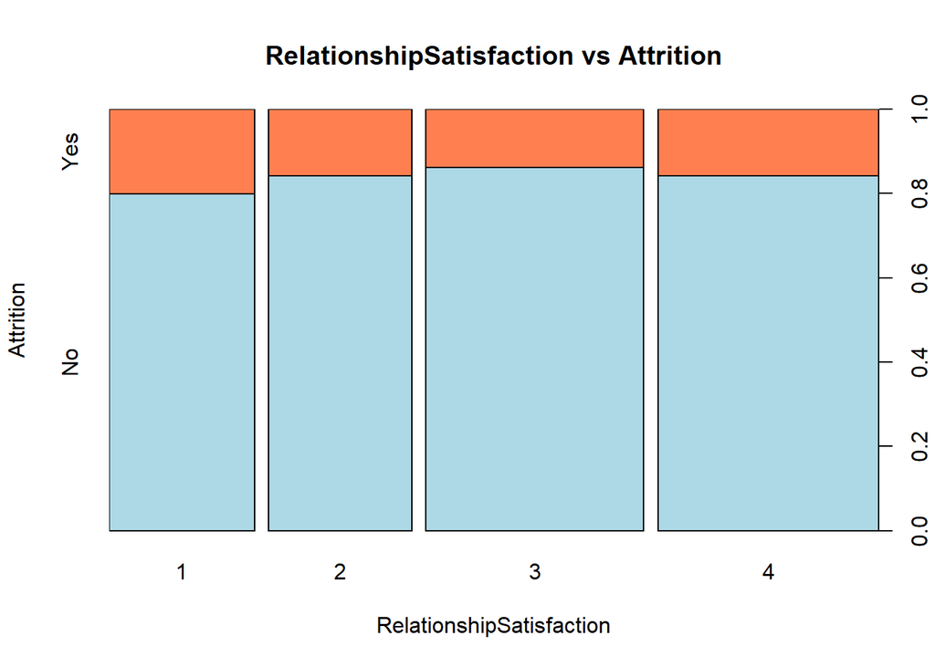

```r
spineplot(x = ddsdata$RelationshipSatisfaction, y = ddsdata$Attrition, xlab = "RelationshipSatisfaction", ylab = "Attrition",
          main = "RelationshipSatisfaction vs Attrition", col = c("lightblue", "coral"), xaxlabels = levels(ddsdata$RelationshipSatisfaction))
```

```r
CrossTable(ddsdata$RelationshipSatisfaction, ddsdata$Attrition)
```

```
##
##
##    Cell Contents
## |-------------------------|
## |                       N |
## | Chi-square contribution |
## |           N / Row Total |
## |           N / Col Total |
## |         N / Table Total |
## |-------------------------|
##
##
## Total Observations in Table:  870
##
##
##                                  | ddsdata$Attrition
## ddsdata$RelationshipSatisfaction |        No |       Yes | Row Total |
## ---------------------------------|-----------|-----------|-----------|
##                                1 |       139 |        35 |       174 |
##                                  |     0.336 |     1.750 |           |
##                                  |     0.799 |     0.201 |     0.200 |
##                                  |     0.190 |     0.250 |           |
##                                  |     0.160 |     0.040 |           |
## ---------------------------------|-----------|-----------|-----------|
##                                2 |       144 |        27 |       171 |
##                                  |     0.002 |     0.010 |           |
##                                  |     0.842 |     0.158 |     0.197 |
##                                  |     0.197 |     0.193 |           |
##                                  |     0.166 |     0.031 |           |
## ---------------------------------|-----------|-----------|-----------|
##                                3 |       225 |        36 |       261 |
##                                  |     0.164 |     0.857 |           |
##                                  |     0.862 |     0.138 |     0.300 |
##                                  |     0.308 |     0.257 |           |
##                                  |     0.259 |     0.041 |           |
## ---------------------------------|-----------|-----------|-----------|
##                                4 |       222 |        42 |       264 |
##                                  |     0.001 |     0.005 |           |
##                                  |     0.841 |     0.159 |     0.303 |
##                                  |     0.304 |     0.300 |           |
##                                  |     0.255 |     0.048 |           |
## ---------------------------------|-----------|-----------|-----------|
##                     Column Total |       730 |       140 |       870 |
##                                  |     0.839 |     0.161 |           |
## ---------------------------------|-----------|-----------|-----------|
##
##
```

```r
chisq.test(ddsdata$RelationshipSatisfaction, ddsdata$Attrition)
```

```
##
##  Pearson's Chi-squared test
##
## data:  ddsdata$RelationshipSatisfaction and ddsdata$Attrition
## X-squared = 3.1253, df = 3, p-value = 0.3727
```

```r
## RelationshipSatisfaction has difference in "yes" and "no" among its categories.
## But P-value of  Chi-Square Test suggests that the variable "RelationshipSatisfaction" has no relationship with response variable. We can remove this variable for final analysis
```

```r
## Summary on StockOptionLevel variable

summary(ddsdata$StockOptionLevel)
```

```
##   0   1   2   3
## 379 355  81  55
```

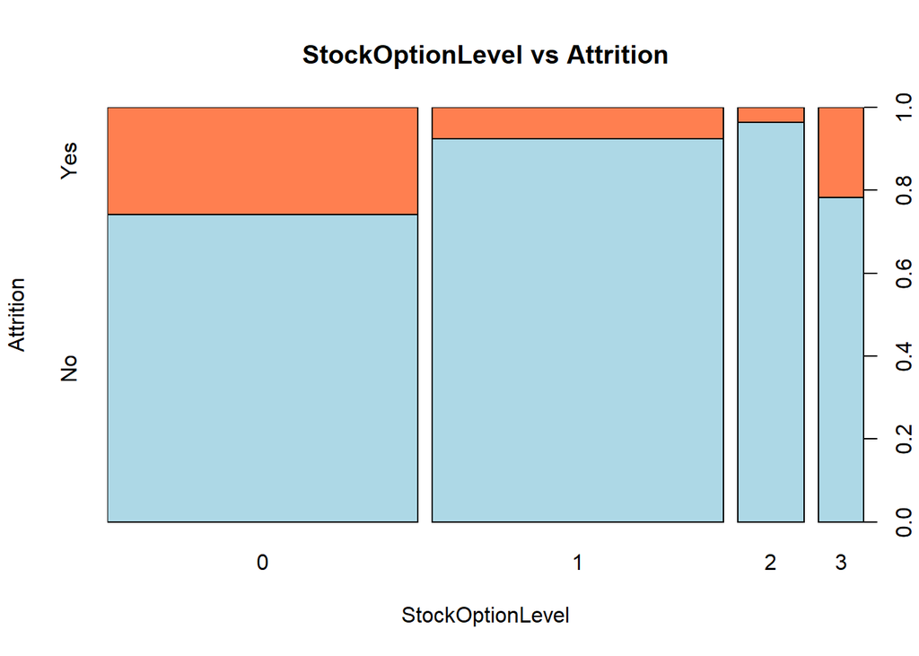

```r
spineplot(x = ddsdata$StockOptionLevel, y = ddsdata$Attrition, xlab = "StockOptionLevel", ylab = "Attrition",
          main = "StockOptionLevel vs Attrition", col = c("lightblue", "coral"), xaxlabels = levels(ddsdata$StockOptionLevel))
```

```r
CrossTable(ddsdata$StockOptionLevel, ddsdata$Attrition)
```

```
##
##
##    Cell Contents
## |-------------------------|
## |                       N |
## | Chi-square contribution |
## |           N / Row Total |
## |           N / Col Total |
## |         N / Table Total |
## |-------------------------|
##
##
## Total Observations in Table:  870
##
##
##                          | ddsdata$Attrition
## ddsdata$StockOptionLevel |        No |       Yes | Row Total |
## -------------------------|-----------|-----------|-----------|
##                        0 |       281 |        98 |       379 |
##                          |     4.308 |    22.461 |           |
##                          |     0.741 |     0.259 |     0.436 |
##                          |     0.385 |     0.700 |           |
##                          |     0.323 |     0.113 |           |
## -------------------------|-----------|-----------|-----------|
##                        1 |       328 |        27 |       355 |
##                          |     3.047 |    15.888 |           |
##                          |     0.924 |     0.076 |     0.408 |
##                          |     0.449 |     0.193 |           |
##                          |     0.377 |     0.031 |           |
## -------------------------|-----------|-----------|-----------|
##                        2 |        78 |         3 |        81 |
##                          |     1.481 |     7.725 |           |
##                          |     0.963 |     0.037 |     0.093 |
##                          |     0.107 |     0.021 |           |
##                          |     0.090 |     0.003 |           |
## -------------------------|-----------|-----------|-----------|
##                        3 |        43 |        12 |        55 |
##                          |     0.215 |     1.121 |           |
##                          |     0.782 |     0.218 |     0.063 |
##                          |     0.059 |     0.086 |           |
##                          |     0.049 |     0.014 |           |
## -------------------------|-----------|-----------|-----------|
##             Column Total |       730 |       140 |       870 |
##                          |     0.839 |     0.161 |           |
## -------------------------|-----------|-----------|-----------|
##
##
```

```r
chisq.test(ddsdata$StockOptionLevel, ddsdata$Attrition)
```

```
##
##  Pearson's Chi-squared test
##
## data:  ddsdata$StockOptionLevel and ddsdata$Attrition
## X-squared = 56.245, df = 3, p-value = 3.724e-12
```

```r
## StockOptionLevel has difference in "yes" and "no" among its categories.
## But P-value of  Chi-Square Test suggests that the variable "StockOptionLevel" has a relationship with response variable. We can keep this variable for final analysis
```

```r
## Summary on TrainingTimesLastYear variable

summary(ddsdata$TrainingTimesLastYear)
```

```
##   0   1   2   3   4   5   6
##  30  39 309 308  73  75  36
```

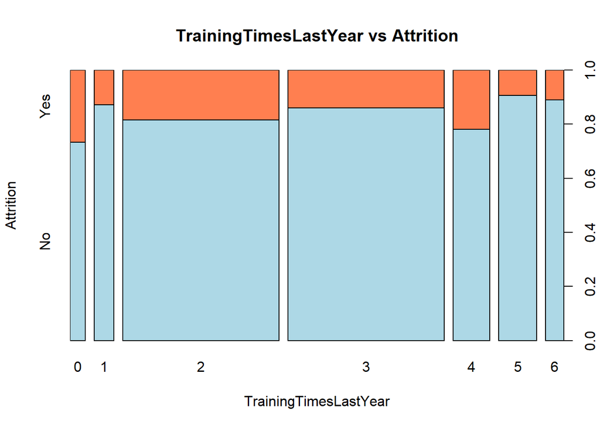

```r
spineplot(x = ddsdata$TrainingTimesLastYear, y = ddsdata$Attrition, xlab = "TrainingTimesLastYear", ylab = "Attrition",
          main = "TrainingTimesLastYear vs Attrition", col = c("lightblue", "coral"), xaxlabels = levels(ddsdata$TrainingTimesLastYear))
```

```r
CrossTable(ddsdata$TrainingTimesLastYear, ddsdata$Attrition)
```

```
##
##
##    Cell Contents
## |-------------------------|
## |                       N |
## | Chi-square contribution |
## |           N / Row Total |
## |           N / Col Total |
## |         N / Table Total |
## |-------------------------|
##
##
## Total Observations in Table:  870
##
##
##                               | ddsdata$Attrition
## ddsdata$TrainingTimesLastYear |        No |       Yes | Row Total |
## ------------------------------|-----------|-----------|-----------|
##                             0 |        22 |         8 |        30 |
##                               |     0.400 |     2.085 |           |
##                               |     0.733 |     0.267 |     0.034 |
##                               |     0.030 |     0.057 |           |
##                               |     0.025 |     0.009 |           |
## ------------------------------|-----------|-----------|-----------|
##                             1 |        34 |         5 |        39 |
##                               |     0.050 |     0.259 |           |
##                               |     0.872 |     0.128 |     0.045 |
##                               |     0.047 |     0.036 |           |
##                               |     0.039 |     0.006 |           |
## ------------------------------|-----------|-----------|-----------|
##                             2 |       252 |        57 |       309 |
##                               |     0.204 |     1.065 |           |
##                               |     0.816 |     0.184 |     0.355 |
##                               |     0.345 |     0.407 |           |
##                               |     0.290 |     0.066 |           |
## ------------------------------|-----------|-----------|-----------|
##                             3 |       265 |        43 |       308 |
##                               |     0.167 |     0.869 |           |
##                               |     0.860 |     0.140 |     0.354 |
##                               |     0.363 |     0.307 |           |
```

[output cut: 10 more lines]

```
##                               |     0.907 |     0.093 |     0.086 |
##                               |     0.093 |     0.050 |           |
##                               |     0.078 |     0.008 |           |
## ------------------------------|-----------|-----------|-----------|
##                             6 |        32 |         4 |        36 |
##                               |     0.106 |     0.555 |           |
##                               |     0.889 |     0.111 |     0.041 |
##                               |     0.044 |     0.029 |           |
##                               |     0.037 |     0.005 |           |
## ------------------------------|-----------|-----------|-----------|
##                  Column Total |       730 |       140 |       870 |
##                               |     0.839 |     0.161 |           |
## ------------------------------|-----------|-----------|-----------|
##
##
```

```r
chisq.test(ddsdata$TrainingTimesLastYear, ddsdata$Attrition)
```

```
##
##  Pearson's Chi-squared test
##
## data:  ddsdata$TrainingTimesLastYear and ddsdata$Attrition
## X-squared = 10.132, df = 6, p-value = 0.1192
```

```r
## TrainingTimesLastYear has difference in "yes" and "no" among its categories.
## But P-value of  Chi-Square Test suggests that the variable "TrainingTimesLastYear" has no relationship with response variable. We can remove this variable for final analysis
```

```r
## Summary on WorkLifeBalance variable

summary(ddsdata$WorkLifeBalance)
```

```
##   1   2   3   4
##  48 192 532  98
```

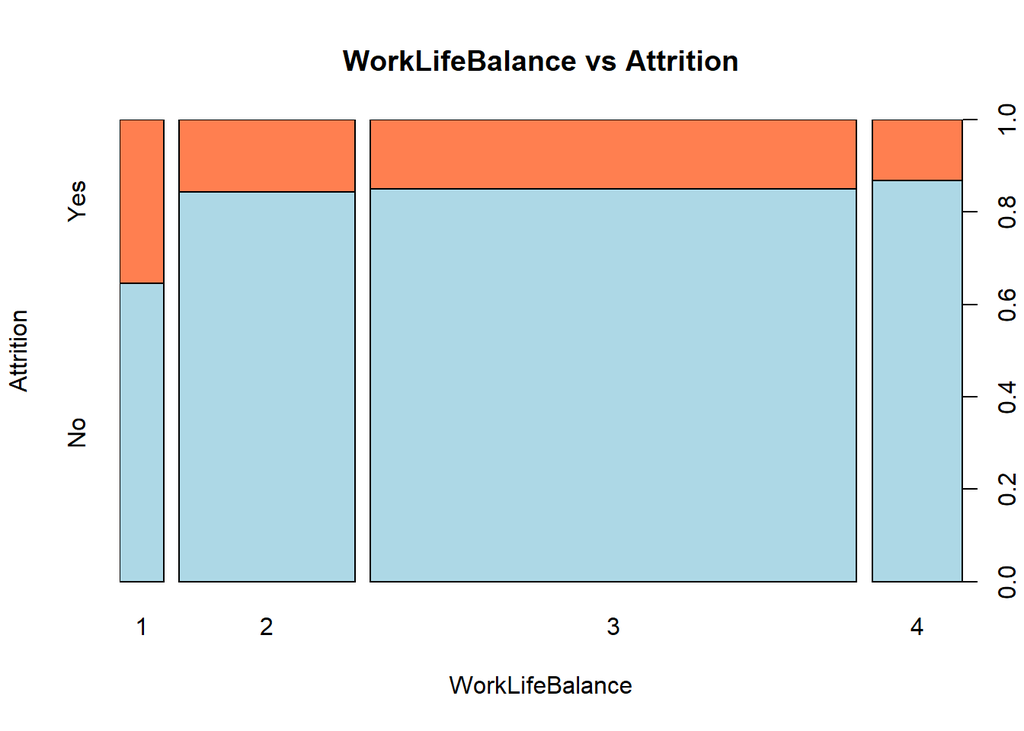

```r
spineplot(x = ddsdata$WorkLifeBalance, y = ddsdata$Attrition, xlab = "WorkLifeBalance", ylab = "Attrition",
          main = "WorkLifeBalance vs Attrition", col = c("lightblue", "coral"), xaxlabels = levels(ddsdata$WorkLifeBalance))
```

```r
CrossTable(ddsdata$WorkLifeBalance, ddsdata$Attrition)
```

```
##
##
##    Cell Contents
## |-------------------------|
## |                       N |
## | Chi-square contribution |
## |           N / Row Total |
## |           N / Col Total |
## |         N / Table Total |
## |-------------------------|
##
##
## Total Observations in Table:  870
##
##
##                         | ddsdata$Attrition
## ddsdata$WorkLifeBalance |        No |       Yes | Row Total |
## ------------------------|-----------|-----------|-----------|
##                       1 |        31 |        17 |        48 |
##                         |     2.136 |    11.139 |           |
##                         |     0.646 |     0.354 |     0.055 |
##                         |     0.042 |     0.121 |           |
##                         |     0.036 |     0.020 |           |
## ------------------------|-----------|-----------|-----------|
##                       2 |       162 |        30 |       192 |
##                         |     0.005 |     0.026 |           |
##                         |     0.844 |     0.156 |     0.221 |
##                         |     0.222 |     0.214 |           |
##                         |     0.186 |     0.034 |           |
## ------------------------|-----------|-----------|-----------|
##                       3 |       452 |        80 |       532 |
##                         |     0.070 |     0.368 |           |
##                         |     0.850 |     0.150 |     0.611 |
##                         |     0.619 |     0.571 |           |
##                         |     0.520 |     0.092 |           |
## ------------------------|-----------|-----------|-----------|
##                       4 |        85 |        13 |        98 |
##                         |     0.093 |     0.487 |           |
##                         |     0.867 |     0.133 |     0.113 |
##                         |     0.116 |     0.093 |           |
##                         |     0.098 |     0.015 |           |
## ------------------------|-----------|-----------|-----------|
##            Column Total |       730 |       140 |       870 |
##                         |     0.839 |     0.161 |           |
## ------------------------|-----------|-----------|-----------|
##
##
```

```r
chisq.test(ddsdata$WorkLifeBalance, ddsdata$Attrition)
```

```
##
##  Pearson's Chi-squared test
##
## data:  ddsdata$WorkLifeBalance and ddsdata$Attrition
## X-squared = 14.325, df = 3, p-value = 0.002495
```

```r
## WorkLifeBalance has difference in "yes" and "no" among its categories.
## But P-value of  Chi-Square Test suggests that the variable "WorkLifeBalance" has a relationship with response variable. We can keep this variable for final analysis
```

# Observations

Based on the Bar plots and Chi-squared test, following variables are significant with response variable EnvironmentSatisfaction JobInvolvement JobLevel JobSatisfaction StockOptionLevel WorkLifeBalance

#Based on low p-values, following variables appear to have the strongest impact on employee attrition: Overtime (p = 1.024e-15) Stock Option Level (p = 3.724e-12) Job Involvement (p = 5.211e-09) Job Level (p = 2.085e-08) Marital Status (p = 3.379e-08)

## EDA on continuous variables

```r
contnames = names(ddsdata)[sapply(ddsdata, class) == "integer" | sapply(ddsdata, class) == "numeric"]

contnames
```

```
##  [1] "ID"                      "Age"
##  [3] "DailyRate"               "DistanceFromHome"
##  [5] "EmployeeCount"           "EmployeeNumber"
##  [7] "HourlyRate"              "MonthlyIncome"
##  [9] "MonthlyRate"             "NumCompaniesWorked"
## [11] "PercentSalaryHike"       "StandardHours"
## [13] "TotalWorkingYears"       "YearsAtCompany"
## [15] "YearsInCurrentRole"      "YearsSinceLastPromotion"
## [17] "YearsWithCurrManager"
```

## EmployeeCount, Over18, StandardHours, EmployeeNumber, ID are not significant continuous varaibles

# Performing pairwise plots with color coding by response which will help in identify any relationships

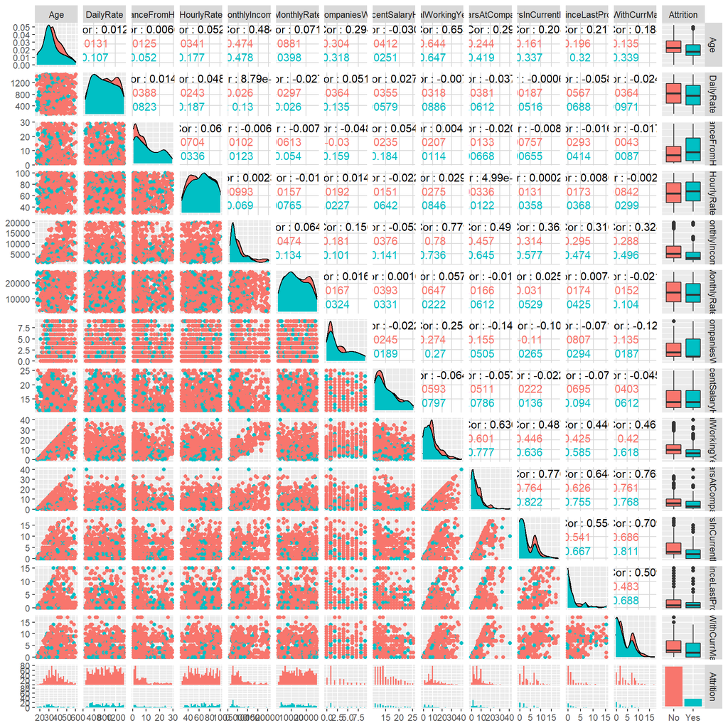

```r
ddsdata %>% dplyr::select(Age, DailyRate, DistanceFromHome, HourlyRate, MonthlyIncome, MonthlyRate, NumCompaniesWorked, PercentSalaryHike,TotalWorkingYears,YearsAtCompany, YearsInCurrentRole, YearsSinceLastPromotion, YearsWithCurrManager, Attrition) %>% ggpairs(aes(color = Attrition)) %>% print(progress=F)
```

## Observations

Looks like YearsWithCurrManager YearsInCurrentRole monthlyincome and TotalWorkingYears appears to be has a relationship with response variable Attrition

## Checking multicolliniarity with Correlation plot

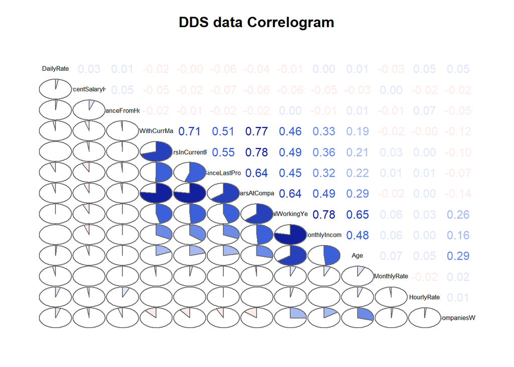

```r
ddsdata_cont = ddsdata %>% dplyr::select(c('Age', 'DailyRate', 'DistanceFromHome', 'HourlyRate', 'MonthlyIncome', 'MonthlyRate', 'NumCompaniesWorked', 'PercentSalaryHike','TotalWorkingYears','YearsAtCompany', 'YearsInCurrentRole', 'YearsSinceLastPromotion', 'YearsWithCurrManager'))

#correlation plot for all continuous variables
corrgram(ddsdata_cont, order=TRUE,
         upper.panel=panel.cor, lower.panel=panel.pie, main="DDS data Correlogram")
```

```r
round(cor(ddsdata_cont, use="pair"),2)
```

```
##                           Age DailyRate DistanceFromHome HourlyRate
## Age                      1.00      0.01             0.01       0.05
## DailyRate                0.01      1.00             0.01       0.05
## DistanceFromHome         0.01      0.01             1.00       0.07
## HourlyRate               0.05      0.05             0.07       1.00
## MonthlyIncome            0.48      0.00            -0.01       0.00
## MonthlyRate              0.07     -0.03            -0.01      -0.02
## NumCompaniesWorked       0.29      0.05            -0.05       0.01
## PercentSalaryHike       -0.03      0.03             0.05      -0.02
## TotalWorkingYears        0.65     -0.01             0.00       0.03
## YearsAtCompany           0.29     -0.04            -0.02       0.00
## YearsInCurrentRole       0.21      0.00            -0.01       0.00
## YearsSinceLastPromotion  0.22     -0.06            -0.02       0.01
## YearsWithCurrManager     0.19     -0.02            -0.02       0.00
##                         MonthlyIncome MonthlyRate NumCompaniesWorked
## Age                              0.48        0.07               0.29
## DailyRate                        0.00       -0.03               0.05
## DistanceFromHome                -0.01       -0.01              -0.05
## HourlyRate                       0.00       -0.02               0.01
## MonthlyIncome                    1.00        0.06               0.16
## MonthlyRate                      0.06        1.00               0.02
## NumCompaniesWorked               0.16        0.02               1.00
## PercentSalaryHike               -0.05        0.00              -0.02
## TotalWorkingYears                0.78        0.06               0.26
## YearsAtCompany                   0.49       -0.02              -0.14
## YearsInCurrentRole               0.36        0.03              -0.10
## YearsSinceLastPromotion          0.32        0.01              -0.07
## YearsWithCurrManager             0.33       -0.02              -0.12
##                         PercentSalaryHike TotalWorkingYears YearsAtCompany
## Age                                 -0.03              0.65           0.29
## DailyRate                            0.03             -0.01          -0.04
## DistanceFromHome                     0.05              0.00          -0.02
## HourlyRate                          -0.02              0.03           0.00
## MonthlyIncome                       -0.05              0.78           0.49
## MonthlyRate                          0.00              0.06          -0.02
## NumCompaniesWorked                  -0.02              0.26          -0.14
## PercentSalaryHike                    1.00             -0.06          -0.06
## TotalWorkingYears                   -0.06              1.00           0.64
## YearsAtCompany                      -0.06              0.64           1.00
## YearsInCurrentRole                  -0.02              0.49           0.78
```

[output cut: 15 more lines]

```
## YearsWithCurrManager                  0.71                    0.51
##                         YearsWithCurrManager
## Age                                     0.19
## DailyRate                              -0.02
## DistanceFromHome                       -0.02
## HourlyRate                              0.00
## MonthlyIncome                           0.33
## MonthlyRate                            -0.02
## NumCompaniesWorked                     -0.12
## PercentSalaryHike                      -0.05
## TotalWorkingYears                       0.46
## YearsAtCompany                          0.77
## YearsInCurrentRole                      0.71
## YearsSinceLastPromotion                 0.51
## YearsWithCurrManager                    1.00
```

## Below variables are highly corrected with each other

# YearsWithCurrManager YearsInCurrentRole 0.71

# YearsWithCurrManager YearsAtCompany 0.77

# YearsAtCompany YearsInCurrentRole 0.78

# TotalWorkingYears MonthlyIncome 0.78

# Creating a balanced dataset

## First of all let’s create a new dataset with our class balanced with oversampling

## Splitting the data into training and test datasets (70-30 split)

```r
set.seed(1008)
ddsdata_new = ddsdata %>% dplyr::select(-c('Attrition', 'EmployeeCount', 'Over18', 'StandardHours', 'EmployeeNumber', 'ID'))

#ddsdata_new = ddsdata %>% dplyr::select(-c('Attrition'))
ddsdata_resp = ddsdata$Attrition
ddsdata_new = cbind(ddsdata_new, ddsdata_resp)
colnames(ddsdata_new)[31] <- "Attrition"

# dataset with "no"
ddsdata_no = ddsdata_new[which(ddsdata_new$Attrition =="No"),]
# dataset with "yes"
ddsdata_yes = ddsdata_new[which(ddsdata_new$Attrition =="Yes"),]

splitPerc = .7 #Training / Test split Percentage

# Training / Test split of "no" dataset
noIndices = sample(1:dim(ddsdata_no)[1],round(splitPerc * dim(ddsdata_no)[1]))
train_no = ddsdata_no[noIndices,]
test_no = ddsdata_no[-noIndices,]

# Training / Test split of "yes" dataset
yesIndices = sample(1:dim(ddsdata_yes)[1],round(splitPerc * dim(ddsdata_yes)[1]))
train_yes = ddsdata_yes[yesIndices,]
test_yes = ddsdata_yes[-yesIndices,]

# Combine training "no" and "yes"
ddsdata_train = rbind(train_no, train_yes)

# Combine test "no" and "yes"
ddsdata_test = rbind(test_no, test_yes)

# upsampling training dataset
ddsdata_train_upsample <- upSample(x = ddsdata_train[, -ncol(ddsdata_train)], y = ddsdata_train$Attrition)
colnames(ddsdata_train_upsample)[31] <- "Attrition"
str(ddsdata_train_upsample$Attrition)
```

```
##  Factor w/ 2 levels "No","Yes": 1 1 1 1 1 1 1 1 1 1 ...
```